# House Prices EDA practice

https://www.google.com/url?q=https%3A%2F%2Fwww.kaggle.com%2Fc%2Fhouse-prices-advanced-regression-techniques

```python
# matplotlib.pyplot: A plotting library used for creating static, animated, and interactive visualizations in Python.
# seaborn: A Python visualization library based on matplotlib that provides a high-level interface for drawing attractive statistical graphics.
# scipy.stats: A module in SciPy that contains a large number of probability distributions and statistical functions.
# numpy: A library for working with arrays and performing numerical computations.

# import modules
import pandas as pd
import numpy as np
import matplotlib as mpl
import matplotlib.pyplot as plt
%matplotlib inline
import seaborn as sns
import scipy.stats as st
from sklearn import ensemble, tree, linear_model
import missingno as msno
```

```python
!pip install missingno #install missingno module
```

#### 1. First, load the data - test and train datasets

```python
train = pd.read_csv("data/train.csv")
test = pd.read_csv("data/test.csv")
```

#### 2. Get quick summary of the data (excludes NaN values) - descriptive statistics

```python
train.describe()
```

|  | Id | MSSubClass | LotFrontage | LotArea | OverallQual | OverallCond | YearBuilt | YearRemodAdd | MasVnrArea | BsmtFinSF1 | ... | WoodDeckSF | OpenPorchSF | EnclosedPorch | 3SsnPorch | ScreenPorch | PoolArea | MiscVal | MoSold | YrSold | SalePrice |
| --- | --- | --- | --- | --- | --- | --- | --- | --- | --- | --- | --- | --- | --- | --- | --- | --- | --- | --- | --- | --- | --- |
| count | 1460.000000 | 1460.000000 | 1201.000000 | 1460.000000 | 1460.000000 | 1460.000000 | 1460.000000 | 1460.000000 | 1452.000000 | 1460.000000 | ... | 1460.000000 | 1460.000000 | 1460.000000 | 1460.000000 | 1460.000000 | 1460.000000 | 1460.000000 | 1460.000000 | 1460.000000 | 1460.000000 |
| mean | 730.500000 | 56.897260 | 70.049958 | 10516.828082 | 6.099315 | 5.575342 | 1971.267808 | 1984.865753 | 103.685262 | 443.639726 | ... | 94.244521 | 46.660274 | 21.954110 | 3.409589 | 15.060959 | 2.758904 | 43.489041 | 6.321918 | 2007.815753 | 180921.195890 |
| std | 421.610009 | 42.300571 | 24.284752 | 9981.264932 | 1.382997 | 1.112799 | 30.202904 | 20.645407 | 181.066207 | 456.098091 | ... | 125.338794 | 66.256028 | 61.119149 | 29.317331 | 55.757415 | 40.177307 | 496.123024 | 2.703626 | 1.328095 | 79442.502883 |
| min | 1.000000 | 20.000000 | 21.000000 | 1300.000000 | 1.000000 | 1.000000 | 1872.000000 | 1950.000000 | 0.000000 | 0.000000 | ... | 0.000000 | 0.000000 | 0.000000 | 0.000000 | 0.000000 | 0.000000 | 0.000000 | 1.000000 | 2006.000000 | 34900.000000 |
| 25% | 365.750000 | 20.000000 | 59.000000 | 7553.500000 | 5.000000 | 5.000000 | 1954.000000 | 1967.000000 | 0.000000 | 0.000000 | ... | 0.000000 | 0.000000 | 0.000000 | 0.000000 | 0.000000 | 0.000000 | 0.000000 | 5.000000 | 2007.000000 | 129975.000000 |
| 50% | 730.500000 | 50.000000 | 69.000000 | 9478.500000 | 6.000000 | 5.000000 | 1973.000000 | 1994.000000 | 0.000000 | 383.500000 | ... | 0.000000 | 25.000000 | 0.000000 | 0.000000 | 0.000000 | 0.000000 | 0.000000 | 6.000000 | 2008.000000 | 163000.000000 |
| 75% | 1095.250000 | 70.000000 | 80.000000 | 11601.500000 | 7.000000 | 6.000000 | 2000.000000 | 2004.000000 | 166.000000 | 712.250000 | ... | 168.000000 | 68.000000 | 0.000000 | 0.000000 | 0.000000 | 0.000000 | 0.000000 | 8.000000 | 2009.000000 | 214000.000000 |
| max | 1460.000000 | 190.000000 | 313.000000 | 215245.000000 | 10.000000 | 9.000000 | 2010.000000 | 2010.000000 | 1600.000000 | 5644.000000 | ... | 857.000000 | 547.000000 | 552.000000 | 508.000000 | 480.000000 | 738.000000 | 15500.000000 | 12.000000 | 2010.000000 | 755000.000000 |

8 rows × 38 columns

#### 3. Get the first and last few rows with 'head' and 'tail' functions of the Pandas library

```python
train.head()
```

|  | Id | MSSubClass | MSZoning | LotFrontage | LotArea | Street | Alley | LotShape | LandContour | Utilities | ... | PoolArea | PoolQC | Fence | MiscFeature | MiscVal | MoSold | YrSold | SaleType | SaleCondition | SalePrice |
| --- | --- | --- | --- | --- | --- | --- | --- | --- | --- | --- | --- | --- | --- | --- | --- | --- | --- | --- | --- | --- | --- |
| 0 | 1 | 60 | RL | 65.0 | 8450 | Pave | NaN | Reg | Lvl | AllPub | ... | 0 | NaN | NaN | NaN | 0 | 2 | 2008 | WD | Normal | 208500 |
| 1 | 2 | 20 | RL | 80.0 | 9600 | Pave | NaN | Reg | Lvl | AllPub | ... | 0 | NaN | NaN | NaN | 0 | 5 | 2007 | WD | Normal | 181500 |
| 2 | 3 | 60 | RL | 68.0 | 11250 | Pave | NaN | IR1 | Lvl | AllPub | ... | 0 | NaN | NaN | NaN | 0 | 9 | 2008 | WD | Normal | 223500 |
| 3 | 4 | 70 | RL | 60.0 | 9550 | Pave | NaN | IR1 | Lvl | AllPub | ... | 0 | NaN | NaN | NaN | 0 | 2 | 2006 | WD | Abnorml | 140000 |
| 4 | 5 | 60 | RL | 84.0 | 14260 | Pave | NaN | IR1 | Lvl | AllPub | ... | 0 | NaN | NaN | NaN | 0 | 12 | 2008 | WD | Normal | 250000 |

5 rows × 81 columns

```python
train.tail()
```

|  | Id | MSSubClass | MSZoning | LotFrontage | LotArea | Street | Alley | LotShape | LandContour | Utilities | ... | PoolArea | PoolQC | Fence | MiscFeature | MiscVal | MoSold | YrSold | SaleType | SaleCondition | SalePrice |
| --- | --- | --- | --- | --- | --- | --- | --- | --- | --- | --- | --- | --- | --- | --- | --- | --- | --- | --- | --- | --- | --- |
| 1455 | 1456 | 60 | RL | 62.0 | 7917 | Pave | NaN | Reg | Lvl | AllPub | ... | 0 | NaN | NaN | NaN | 0 | 8 | 2007 | WD | Normal | 175000 |
| 1456 | 1457 | 20 | RL | 85.0 | 13175 | Pave | NaN | Reg | Lvl | AllPub | ... | 0 | NaN | MnPrv | NaN | 0 | 2 | 2010 | WD | Normal | 210000 |
| 1457 | 1458 | 70 | RL | 66.0 | 9042 | Pave | NaN | Reg | Lvl | AllPub | ... | 0 | NaN | GdPrv | Shed | 2500 | 5 | 2010 | WD | Normal | 266500 |
| 1458 | 1459 | 20 | RL | 68.0 | 9717 | Pave | NaN | Reg | Lvl | AllPub | ... | 0 | NaN | NaN | NaN | 0 | 4 | 2010 | WD | Normal | 142125 |
| 1459 | 1460 | 20 | RL | 75.0 | 9937 | Pave | NaN | Reg | Lvl | AllPub | ... | 0 | NaN | NaN | NaN | 0 | 6 | 2008 | WD | Normal | 147500 |

5 rows × 81 columns

#### Show shape of test and train

```python
train.shape, test.shape
```

```
((1460, 81), (1459, 80))
```

#### 4. We examine the numeric and categorical features in the dataset

```python
numeric_features = train.select_dtypes(include=[np.number])
print(numeric_features.columns)
```

```
Index(['Id', 'MSSubClass', 'LotFrontage', 'LotArea', 'OverallQual',
       'OverallCond', 'YearBuilt', 'YearRemodAdd', 'MasVnrArea', 'BsmtFinSF1',
       'BsmtFinSF2', 'BsmtUnfSF', 'TotalBsmtSF', '1stFlrSF', '2ndFlrSF',
       'LowQualFinSF', 'GrLivArea', 'BsmtFullBath', 'BsmtHalfBath', 'FullBath',
       'HalfBath', 'BedroomAbvGr', 'KitchenAbvGr', 'TotRmsAbvGrd',
       'Fireplaces', 'GarageYrBlt', 'GarageCars', 'GarageArea', 'WoodDeckSF',
       'OpenPorchSF', 'EnclosedPorch', '3SsnPorch', 'ScreenPorch', 'PoolArea',
       'MiscVal', 'MoSold', 'YrSold', 'SalePrice'],
      dtype='object')
```

```python
categorical_features = train.select_dtypes(include='object')
print(categorical_features.columns)
```

```
Index(['MSZoning', 'Street', 'Alley', 'LotShape', 'LandContour', 'Utilities',
       'LotConfig', 'LandSlope', 'Neighborhood', 'Condition1', 'Condition2',
       'BldgType', 'HouseStyle', 'RoofStyle', 'RoofMatl', 'Exterior1st',
       'Exterior2nd', 'MasVnrType', 'ExterQual', 'ExterCond', 'Foundation',
       'BsmtQual', 'BsmtCond', 'BsmtExposure', 'BsmtFinType1', 'BsmtFinType2',
       'Heating', 'HeatingQC', 'CentralAir', 'Electrical', 'KitchenQual',
       'Functional', 'FireplaceQu', 'GarageType', 'GarageFinish', 'GarageQual',
       'GarageCond', 'PavedDrive', 'PoolQC', 'Fence', 'MiscFeature',
       'SaleType', 'SaleCondition'],
      dtype='object')
```

#### 5. a. Visualising data.... msno--is the Python library used for visualizing missing data in a dataset.

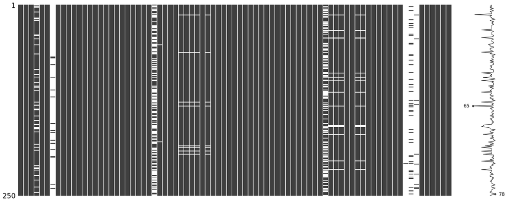

```python
# visualise missing data for a sample of 250
msno.matrix(train.sample(250))
```

#### 5b. Heatmap

The missingno correlation heatmap measures nullity correlation: how strongly the presence or absence of one variable affects the presence of another:

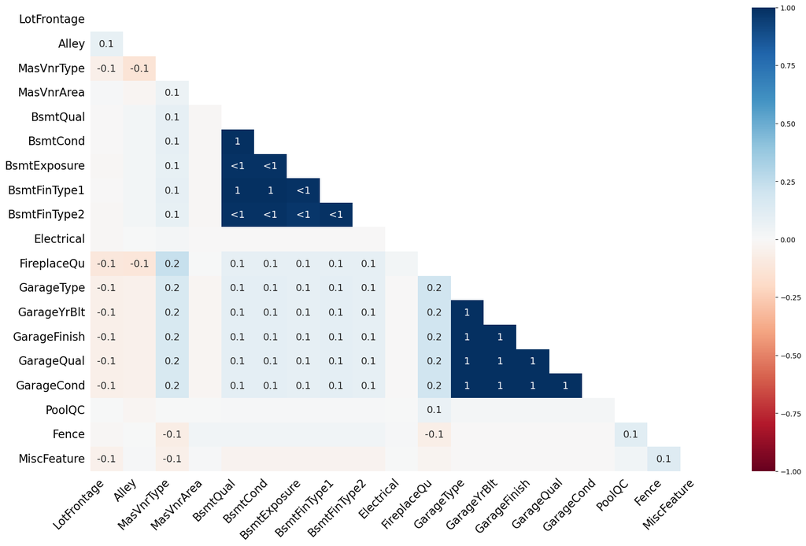

```python
msno.heatmap(train)
```

#### 5c. Missing values Visualisation... Overall Purpose: The primary use of this line of code is to quickly assess the completeness of the data in different columns of the train DataFrame. It helps in identifying which columns have missing data and to what extent, which is crucial for data cleaning and preprocessing in any data analysis or machine learning task.

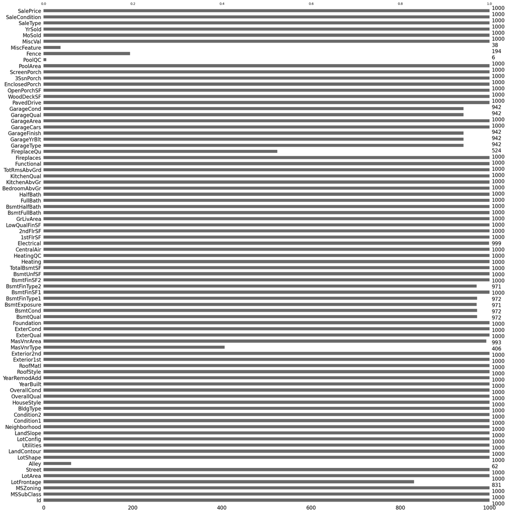

```python
msno.bar(train.sample(1000))
```

#### 5d. Dendogram: The dendrogram allows you to more fully correlate variable completion, revealing trends deeper than the pairwise ones visible in the correlation heatmap:

#### Understanding the Dendrogram: NEW

- Each branch of the dendrogram represents a variable in your dataset. Variables that are grouped together (i.e., branches that emerge from a common "root") tend to have similar patterns of missing data. The arrangement helps you understand which variables have missing values that are correlated or occur together.
- Usage: This function is particularly useful in the exploratory data analysis phase to understand the structure of missingness in your data. By identifying patterns of missing data, it can help in formulating strategies for handling missing values, such as imputation, or in identifying potential issues with data collection processes.

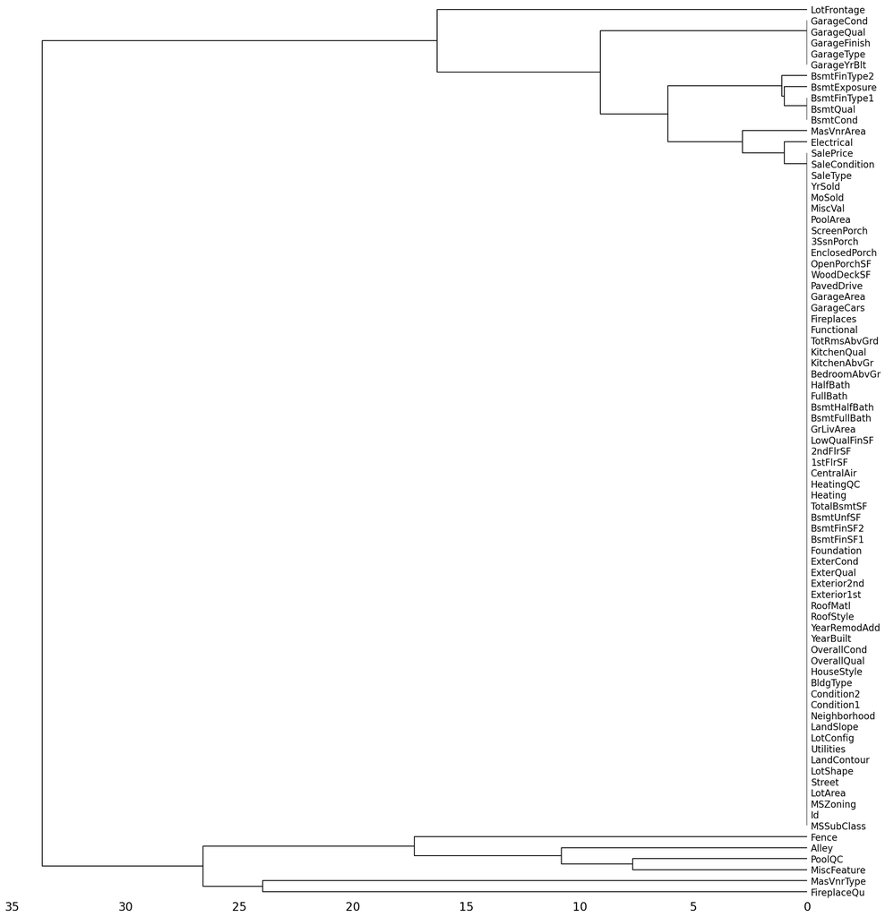

```python
msno.dendrogram(train)
```

#### 6a. Estimate skewness and kurtosis

- Skewness: If your training dataset has a high skewness, it could lead to biased models, especially in linear models like regression. For example, right-skewed data might lead a model to predict higher values more often. You might need to transform the data (e.g., using a logarithmic transformation) to reduce skewness.
- Kurtosis: High kurtosis might indicate the presence of outliers that could affect the model's performance. Models like linear regression can be particularly sensitive to outliers, so it’s important to detect and possibly address them.

```python
train.skew(numeric_only=True), train.kurtosis(numeric_only=True)
```

```
(Id                0.000000
 MSSubClass        1.407657
 LotFrontage       2.163569
 LotArea          12.207688
 OverallQual       0.216944
 OverallCond       0.693067
 YearBuilt        -0.613461
 YearRemodAdd     -0.503562
 MasVnrArea        2.669084
 BsmtFinSF1        1.685503
 BsmtFinSF2        4.255261
 BsmtUnfSF         0.920268
 TotalBsmtSF       1.524255
 1stFlrSF          1.376757
 2ndFlrSF          0.813030
 LowQualFinSF      9.011341
 GrLivArea         1.366560
 BsmtFullBath      0.596067
 BsmtHalfBath      4.103403
 FullBath          0.036562
 HalfBath          0.675897
 BedroomAbvGr      0.211790
 KitchenAbvGr      4.488397
 TotRmsAbvGrd      0.676341
 Fireplaces        0.649565
 GarageYrBlt      -0.649415
 GarageCars       -0.342549
 GarageArea        0.179981
 WoodDeckSF        1.541376
 OpenPorchSF       2.364342
 EnclosedPorch     3.089872
 3SsnPorch        10.304342
 ScreenPorch       4.122214
 PoolArea         14.828374
 MiscVal          24.476794
 MoSold            0.212053
 YrSold            0.096269
 SalePrice         1.882876
 dtype: float64,
 Id                -1.200000
```

[output cut: 23 more lines]

```
 Fireplaces        -0.217237
 GarageYrBlt       -0.418341
 GarageCars         0.220998
 GarageArea         0.917067
 WoodDeckSF         2.992951
 OpenPorchSF        8.490336
 EnclosedPorch     10.430766
 3SsnPorch        123.662379
 ScreenPorch       18.439068
 PoolArea         223.268499
 MiscVal          701.003342
 MoSold            -0.404109
 YrSold            -1.190601
 SalePrice          6.536282
 dtype: float64)
```

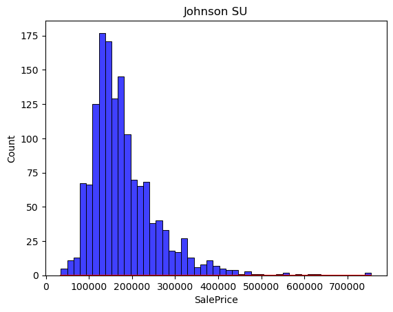

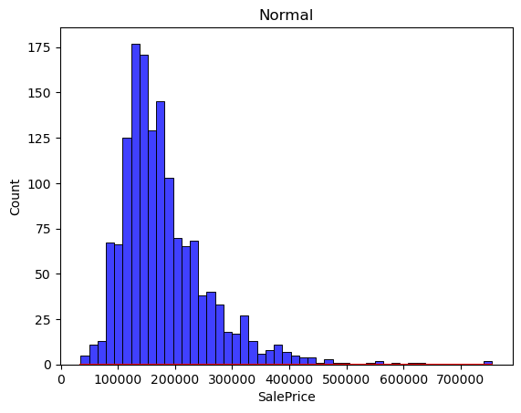

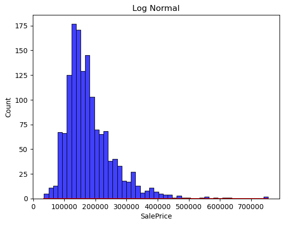

```python
# Extract the SalePrice column from the DataFrame train and assigns it to the variable y.
y = train['SalePrice']
# Generate 1,000 evenly spaced points between the minimum and maximum values of y. This array x will
# be used to evaluate the Johnson SU, Normal, and Log-normal distribution.
x = np.linspace(y.min(), y.max(), 1000)

# Johnson SU Distribution
plt.figure(1)
plt.title('Johnson SU')
# Plot a histogram of the SalePrice data (y) in blue without displaying the kernel density estimate (kde=False).
sns.histplot(y, kde=False, color="blue")
# Fit the SalePrice data (y) to a Johnson SU distribution and return the parameters of the distribution.
# These parameters are stored in johnson_su_params.
johnson_su_params = st.johnsonsu.fit(y)

# st.johnsonsu.pdf(x, *johnson_su_params): Computes the probability density function (PDF) of the Johnson SU distribution
# at each point in x using the fitted parameters. plt.plot(x, ..., 'r'): Plots the PDF of the Johnson SU distribution in
# red ('r') on top of the histogram.
plt.plot(x, st.johnsonsu.pdf(x, *johnson_su_params), 'r')

# Normal Distribution
plt.figure(2)
plt.title('Normal')
sns.histplot(y, kde=False, color="blue")
# Fit the data to a normal distribution and plot it
norm_params = st.norm.fit(y)
plt.plot(x, st.norm.pdf(x, *norm_params), 'r')

# Log Normal Distribution
plt.figure(3)
plt.title('Log Normal')
sns.histplot(y, kde=False, color="blue")
# Fit the data to a log normal distribution and plot it
lognorm_params = st.lognorm.fit(y)
plt.plot(x, st.lognorm.pdf(x, *lognorm_params), 'r')

plt.show()
```